# Kira_Plastinina_Research

Bundi Kirimi

1/30/2022

#Installing packages.

```r
#install.packages("devtools")

#install_github("vqv/ggbiplot")
#install.packages("rtools")
#install.packages("DataExplorer")
#install.packages("Hmisc")
#install.packages("pastecs")
#install.packages("psych")
#install.packages("corrplot")
#install.packages("factoextra")
#install.packages("caret")
```

#Loading the libraries

```r
#specify the path where the file is located
library("data.table")
library(tidyverse)
library(magrittr)
```

```r
library(warn = -1)
library("ggbiplot")
library(ggplot2)
library(lattice)
library(corrplot)
library(DataExplorer)
library(pastecs)
library(psych)
library(factoextra)
library(caret)
```

#Loading the data

```r
library("data.table")
library("readr")


data <- read.csv("http://bit.ly/EcommerceCustomersDataset")
head(data)
```

```
##   Administrative Administrative_Duration Informational Informational_Duration
## 1              0                       0             0                      0
## 2              0                       0             0                      0
## 3              0                      -1             0                     -1
## 4              0                       0             0                      0
## 5              0                       0             0                      0
## 6              0                       0             0                      0
##   ProductRelated ProductRelated_Duration BounceRates ExitRates PageValues
## 1              1                0.000000  0.20000000 0.2000000          0
## 2              2               64.000000  0.00000000 0.1000000          0
## 3              1               -1.000000  0.20000000 0.2000000          0
## 4              2                2.666667  0.05000000 0.1400000          0
## 5             10              627.500000  0.02000000 0.0500000          0
## 6             19              154.216667  0.01578947 0.0245614          0
##   SpecialDay Month OperatingSystems Browser Region TrafficType
## 1          0   Feb                1       1      1           1
## 2          0   Feb                2       2      1           2
## 3          0   Feb                4       1      9           3
## 4          0   Feb                3       2      2           4
## 5          0   Feb                3       3      1           4
## 6          0   Feb                2       2      1           3
##         VisitorType Weekend Revenue
## 1 Returning_Visitor   FALSE   FALSE
## 2 Returning_Visitor   FALSE   FALSE
## 3 Returning_Visitor   FALSE   FALSE
## 4 Returning_Visitor   FALSE   FALSE
## 5 Returning_Visitor    TRUE   FALSE
## 6 Returning_Visitor   FALSE   FALSE
```

```r
df <- data.frame(data)
head(df)
```

```
##   Administrative Administrative_Duration Informational Informational_Duration
## 1              0                       0             0                      0
## 2              0                       0             0                      0
## 3              0                      -1             0                     -1
## 4              0                       0             0                      0
## 5              0                       0             0                      0
## 6              0                       0             0                      0
##   ProductRelated ProductRelated_Duration BounceRates ExitRates PageValues
## 1              1                0.000000  0.20000000 0.2000000          0
## 2              2               64.000000  0.00000000 0.1000000          0
## 3              1               -1.000000  0.20000000 0.2000000          0
## 4              2                2.666667  0.05000000 0.1400000          0
## 5             10              627.500000  0.02000000 0.0500000          0
## 6             19              154.216667  0.01578947 0.0245614          0
##   SpecialDay Month OperatingSystems Browser Region TrafficType
## 1          0   Feb                1       1      1           1
## 2          0   Feb                2       2      1           2
## 3          0   Feb                4       1      9           3
## 4          0   Feb                3       2      2           4
## 5          0   Feb                3       3      1           4
## 6          0   Feb                2       2      1           3
##         VisitorType Weekend Revenue
## 1 Returning_Visitor   FALSE   FALSE
## 2 Returning_Visitor   FALSE   FALSE
## 3 Returning_Visitor   FALSE   FALSE
## 4 Returning_Visitor   FALSE   FALSE
## 5 Returning_Visitor    TRUE   FALSE
## 6 Returning_Visitor   FALSE   FALSE
```

#Previewing the summary of the dataset

```r
summary(df)
```

```
##  Administrative   Administrative_Duration Informational
##  Min.   : 0.000   Min.   :  -1.00         Min.   : 0.000
##  1st Qu.: 0.000   1st Qu.:   0.00         1st Qu.: 0.000
##  Median : 1.000   Median :   8.00         Median : 0.000
##  Mean   : 2.318   Mean   :  80.91         Mean   : 0.504
##  3rd Qu.: 4.000   3rd Qu.:  93.50         3rd Qu.: 0.000
##  Max.   :27.000   Max.   :3398.75         Max.   :24.000
##  NA's   :14       NA's   :14              NA's   :14
##  Informational_Duration ProductRelated   ProductRelated_Duration
##  Min.   :  -1.00        Min.   :  0.00   Min.   :   -1.0
##  1st Qu.:   0.00        1st Qu.:  7.00   1st Qu.:  185.0
##  Median :   0.00        Median : 18.00   Median :  599.8
##  Mean   :  34.51        Mean   : 31.76   Mean   : 1196.0
##  3rd Qu.:   0.00        3rd Qu.: 38.00   3rd Qu.: 1466.5
##  Max.   :2549.38        Max.   :705.00   Max.   :63973.5
##  NA's   :14             NA's   :14       NA's   :14
##   BounceRates         ExitRates         PageValues        SpecialDay
##  Min.   :0.000000   Min.   :0.00000   Min.   :  0.000   Min.   :0.00000
##  1st Qu.:0.000000   1st Qu.:0.01429   1st Qu.:  0.000   1st Qu.:0.00000
##  Median :0.003119   Median :0.02512   Median :  0.000   Median :0.00000
##  Mean   :0.022152   Mean   :0.04300   Mean   :  5.889   Mean   :0.06143
##  3rd Qu.:0.016684   3rd Qu.:0.05000   3rd Qu.:  0.000   3rd Qu.:0.00000
##  Max.   :0.200000   Max.   :0.20000   Max.   :361.764   Max.   :1.00000
##  NA's   :14         NA's   :14
##     Month           OperatingSystems    Browser           Region
##  Length:12330       Min.   :1.000    Min.   : 1.000   Min.   :1.000
##  Class :character   1st Qu.:2.000    1st Qu.: 2.000   1st Qu.:1.000
##  Mode  :character   Median :2.000    Median : 2.000   Median :3.000
##                     Mean   :2.124    Mean   : 2.357   Mean   :3.147
##                     3rd Qu.:3.000    3rd Qu.: 2.000   3rd Qu.:4.000
##                     Max.   :8.000    Max.   :13.000   Max.   :9.000
##
##   TrafficType    VisitorType         Weekend         Revenue
##  Min.   : 1.00   Length:12330       Mode :logical   Mode :logical
##  1st Qu.: 2.00   Class :character   FALSE:9462      FALSE:10422
##  Median : 2.00   Mode  :character   TRUE :2868      TRUE :1908
##  Mean   : 4.07
##  3rd Qu.: 4.00
##  Max.   :20.00
##
```

#Checking the data

```r
#Length
length(df)
```

```
## [1] 18
```

The dataframe has 18 columns

```r
#Dimensions
dim(df)
```

```
## [1] 12330    18
```

#The dataframe has 12330 row entries and 18 columns Column Names

```r
colnames(df)
```

```
##  [1] "Administrative"          "Administrative_Duration"
##  [3] "Informational"           "Informational_Duration"
##  [5] "ProductRelated"          "ProductRelated_Duration"
##  [7] "BounceRates"             "ExitRates"
##  [9] "PageValues"              "SpecialDay"
## [11] "Month"                   "OperatingSystems"
## [13] "Browser"                 "Region"
## [15] "TrafficType"             "VisitorType"
## [17] "Weekend"                 "Revenue"
```

Column data types

```r
sapply(df, class)
```

```
##          Administrative Administrative_Duration           Informational
##               "integer"               "numeric"               "integer"
##  Informational_Duration          ProductRelated ProductRelated_Duration
##               "numeric"               "integer"               "numeric"
##             BounceRates               ExitRates              PageValues
##               "numeric"               "numeric"               "numeric"
##              SpecialDay                   Month        OperatingSystems
##               "numeric"             "character"               "integer"
##                 Browser                  Region             TrafficType
##               "integer"               "integer"               "integer"
##             VisitorType                 Weekend                 Revenue
##             "character"               "logical"               "logical"
```

#Data Cleaning

```r
is.na(df)
```

[output not shown]

[output cut: 22210 more lines]

```r
any(is.na(df))
```

```
## [1] TRUE
```

```r
#Missing Values
sum(is.na(df))
```

```
## [1] 112
```

#Columns with missing values

```r
#Checking the sum of missing values per column
colSums(is.na(df))
```

```
##          Administrative Administrative_Duration           Informational
##                      14                      14                      14
##  Informational_Duration          ProductRelated ProductRelated_Duration
##                      14                      14                      14
##             BounceRates               ExitRates              PageValues
##                      14                      14                       0
##              SpecialDay                   Month        OperatingSystems
##                       0                       0                       0
##                 Browser                  Region             TrafficType
##                       0                       0                       0
##             VisitorType                 Weekend                 Revenue
##                       0                       0                       0
```

```r
#Duplicates
duplicated_rows <- df[duplicated(df),]
dim(duplicated_rows)
```

```
## [1] 119  18
```

Removing duplicates

```r
new_df <- df[-which(duplicated(df)), ]
dim(new_df)
```

```
## [1] 12211    18
```

#Data Types

```r
sapply(new_df, class)
```

```
##          Administrative Administrative_Duration           Informational
##               "integer"               "numeric"               "integer"
##  Informational_Duration          ProductRelated ProductRelated_Duration
##               "numeric"               "integer"               "numeric"
##             BounceRates               ExitRates              PageValues
##               "numeric"               "numeric"               "numeric"
##              SpecialDay                   Month        OperatingSystems
##               "numeric"             "character"               "integer"
##                 Browser                  Region             TrafficType
##               "integer"               "integer"               "integer"
##             VisitorType                 Weekend                 Revenue
##             "character"               "logical"               "logical"
```

#Univariate Analysis ##Administrative

```r
unique(new_df$Administrative)
```

```
##  [1]  0  1  2  4 12  3 10  6  5  9  8 16 13 11  7 18 14 17 19 15 NA 24 22 21 20
## [26] 23 27 26
```

```r
factor(unique(new_df$Administrative))
```

```
##  [1] 0    1    2    4    12   3    10   6    5    9    8    16   13   11   7
## [16] 18   14   17   19   15   <NA> 24   22   21   20   23   27   26
## 27 Levels: 0 1 2 3 4 5 6 7 8 9 10 11 12 13 14 15 16 17 18 19 20 21 22 23 ... 27
```

#There are 27 levels [27 unique elements in the Administrative column

```r
length(new_df$Administrative)
```

```
## [1] 12211
```

```r
dim(new_df)
```

```
## [1] 12211    18
```

```r
sum(is.na(new_df))
```

```
## [1] 96
```

#there are 96 missing values in the new_market_df dataframe

```r
df2 <- new_df[-which(is.na(new_df)), ]
sum(is.na(df2))
```

```
## [1] 0
```

```r
dim(df2)
```

```
## [1] 12199    18
```

```r
colSums(is.na(df2))
```

```
##          Administrative Administrative_Duration           Informational
##                       0                       0                       0
##  Informational_Duration          ProductRelated ProductRelated_Duration
##                       0                       0                       0
##             BounceRates               ExitRates              PageValues
##                       0                       0                       0
##              SpecialDay                   Month        OperatingSystems
##                       0                       0                       0
##                 Browser                  Region             TrafficType
##                       0                       0                       0
##             VisitorType                 Weekend                 Revenue
##                       0                       0                       0
```

```r
summary(df2$Administrative)
```

```
##    Min. 1st Qu.  Median    Mean 3rd Qu.    Max.
##    0.00    0.00    1.00    2.34    4.00   27.00
```

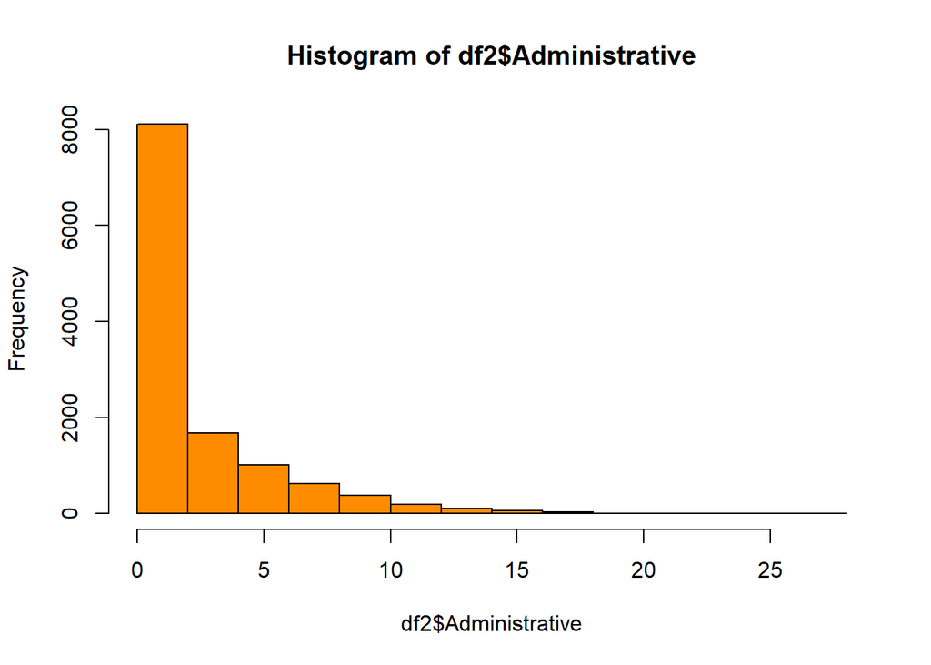

```r
#each of the values printed below appear thrice in the dataset
#distribution
hist(df2$Administrative, col=c("darkorange"))
```

The adm distribution is right skewed. The highest value in the administrative column is 27 The lowest value in the column is zero and it has the highest frequency. The mean is 2.34

##Administrative_Duration

```r
length(unique(df2$Administrative_Duration))
```

```
## [1] 3336
```

```r
summary(df2$Administrative_Duration)
```

```
##    Min. 1st Qu.  Median    Mean 3rd Qu.    Max.
##   -1.00    0.00    9.00   81.68   94.75 3398.75
```

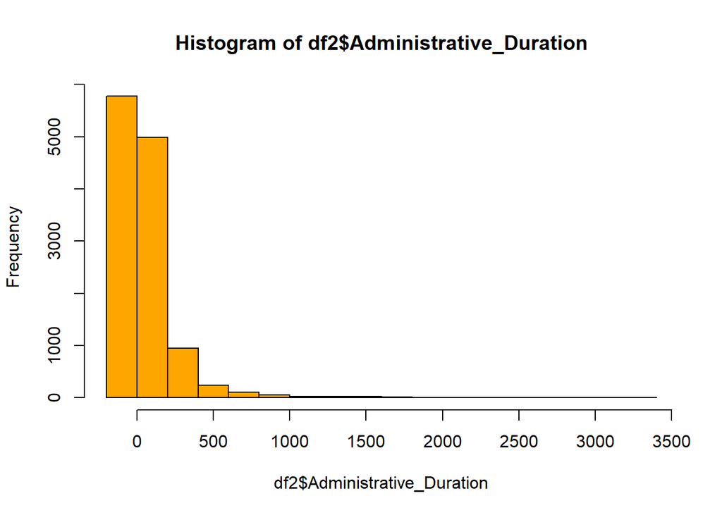

```r
#distribution
hist(df2$Administrative_Duration, col=c("orange"))
```

#Informational

```r
length(unique(df2$Informational))
```

```
## [1] 17
```

```r
#there are 17 unique elements in Informational column
summary(df2$Informational)
```

```
##    Min. 1st Qu.  Median    Mean 3rd Qu.    Max.
##  0.0000  0.0000  0.0000  0.5088  0.0000 24.0000
```

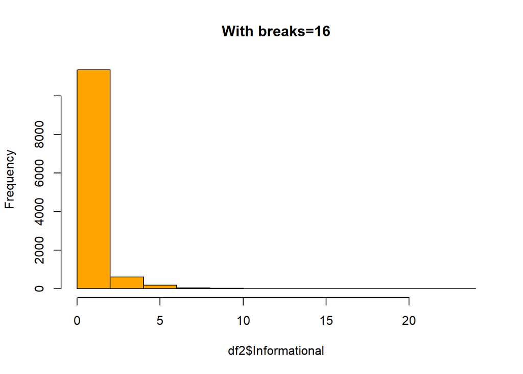

```r
#distribution
hist(df2$Informational,breaks = 16 , main="With breaks=16", col=c("Orange"))
```

Informational_Duration

```r
length(unique(df2$Informational_Duration))
```

```
## [1] 1259
```

```r
#there are 1259 unique elements in Informational duration column

summary(df2$Informational_Duration)
```

```
##    Min. 1st Qu.  Median    Mean 3rd Qu.    Max.
##   -1.00    0.00    0.00   34.84    0.00 2549.38
```

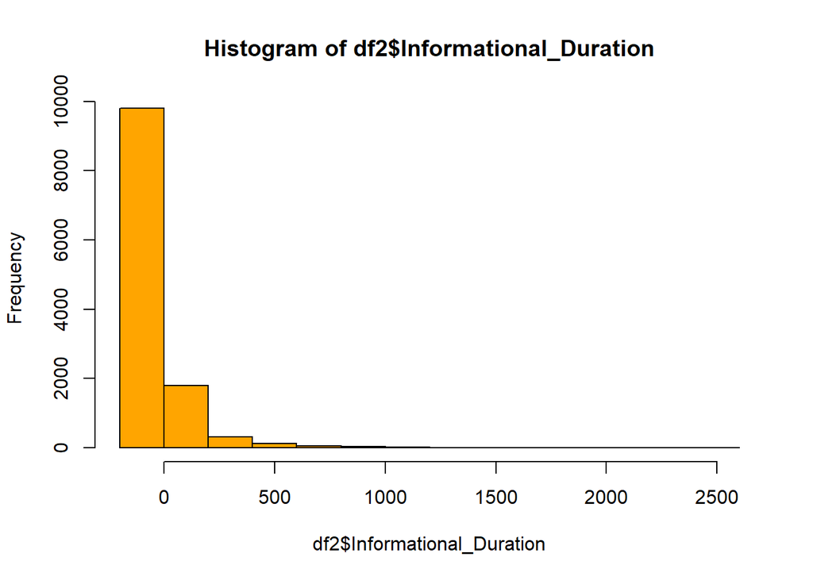

```r
#distribution
hist(df2$Informational_Duration,col=c("Orange"))
```

ProductRelated

```r
length(unique(df2$ProductRelated))
```

```
## [1] 311
```

```r
#there are 311 unique elements in Product Related  column

summary(df2$ProductRelated)
```

```
##    Min. 1st Qu.  Median    Mean 3rd Qu.    Max.
##    0.00    8.00   18.00   32.06   38.00  705.00
```

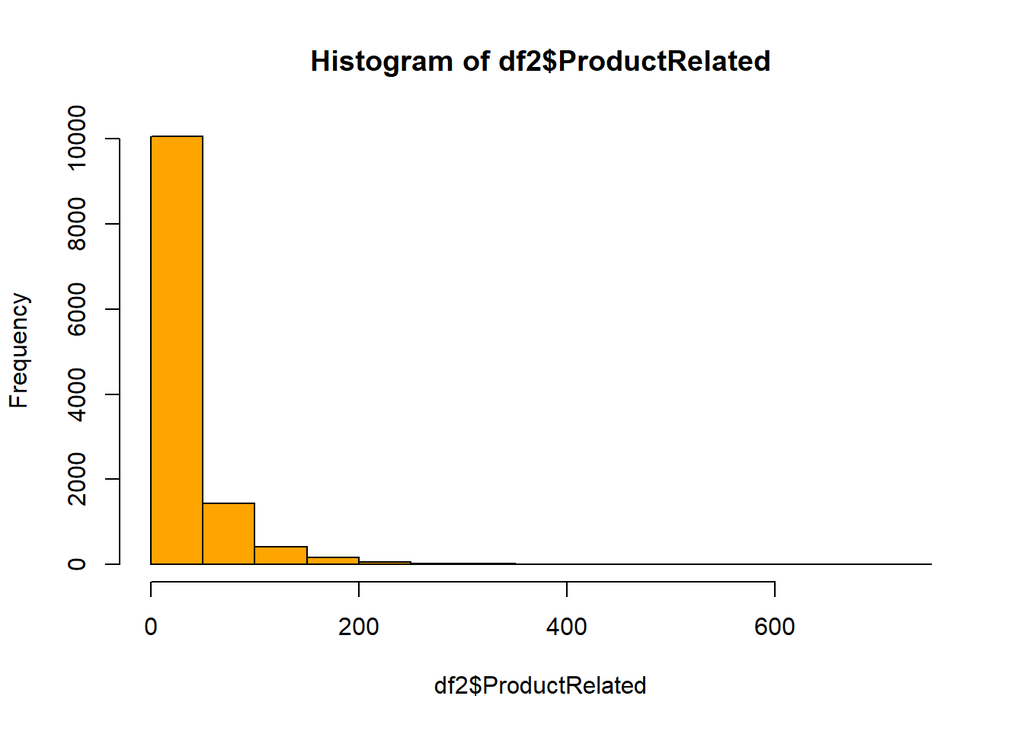

```r
#distribution
hist(df2$ProductRelated,col=c("Orange"))
```

ProductRelated Duration

```r
length(unique(df2$ProductRelated_Duration))
```

```
## [1] 9552
```

```r
#there are 311 unique elements in Product Related  column

summary(df2$ProductRelated_Duration)
```

```
##    Min. 1st Qu.  Median    Mean 3rd Qu.    Max.
##    -1.0   193.6   609.5  1207.5  1477.6 63973.5
```

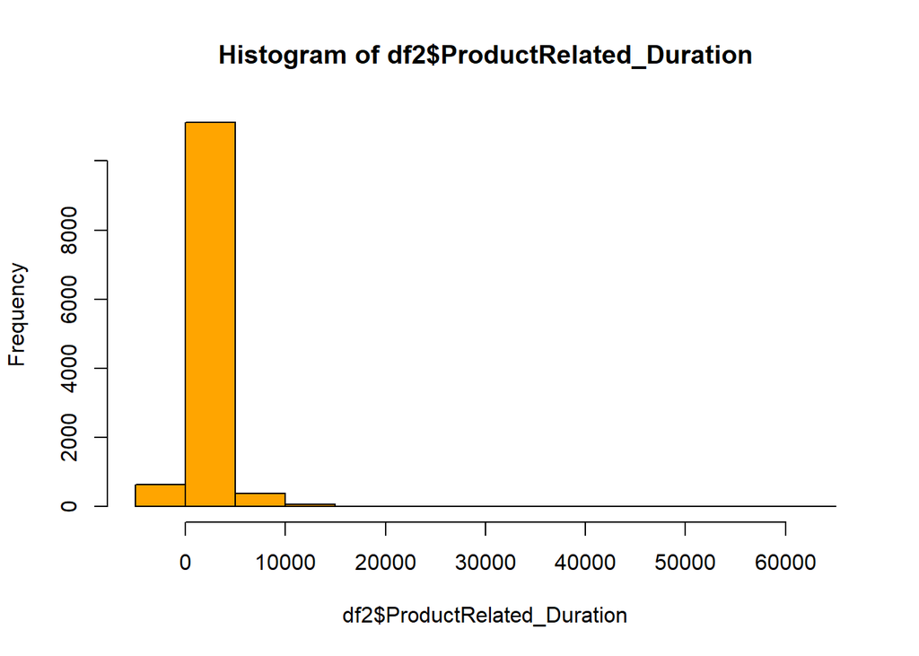

```r
#distribution
hist(df2$ProductRelated_Duration,col=c("Orange"))
```

Bounce Rates

```r
length(unique(df2$BounceRates))
```

```
## [1] 1872
```

```r
#there are 311 unique elements in Product Related  column

summary(df2$BounceRates)
```

```
##    Min. 1st Qu.  Median    Mean 3rd Qu.    Max.
## 0.00000 0.00000 0.00293 0.02045 0.01667 0.20000
```

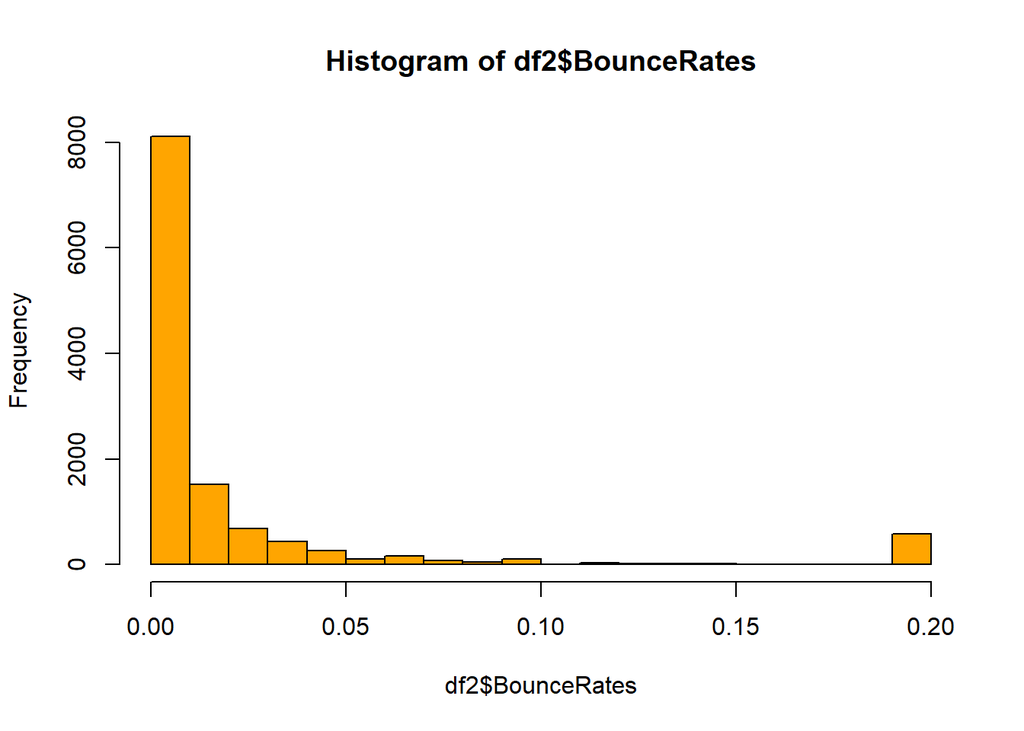

```r
#distribution
hist(df2$BounceRates,col=c("Orange"))
```

Exit Rates

```r
length(unique(df2$ExitRates))
```

```
## [1] 4777
```

```r
#there are 311 unique elements in Product Related  column

summary(df2$ExitRates)
```

```
##    Min. 1st Qu.  Median    Mean 3rd Qu.    Max.
## 0.00000 0.01422 0.02500 0.04150 0.04848 0.20000
```

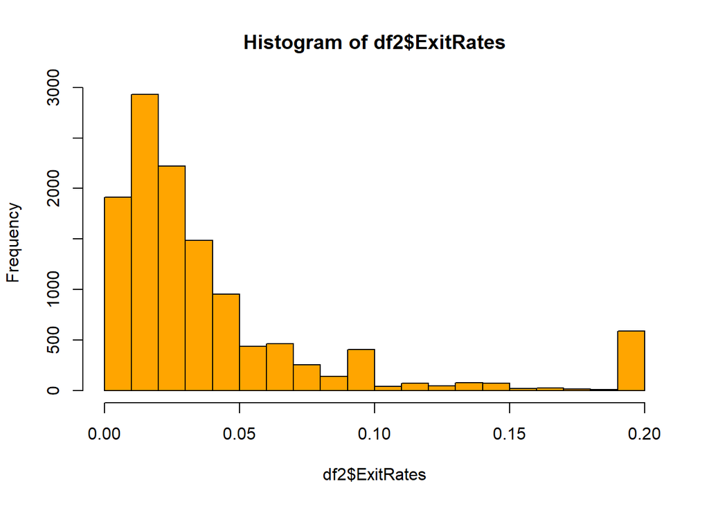

```r
#distribution
hist(df2$ExitRates,col=c("Orange"))
```

Page Values

```r
length(unique(df2$PageValues))
```

```
## [1] 2704
```

```r
#there are 311 unique elements in Product Related  column

summary(df2$PageValues)
```

```
##    Min. 1st Qu.  Median    Mean 3rd Qu.    Max.
##   0.000   0.000   0.000   5.952   0.000 361.764
```

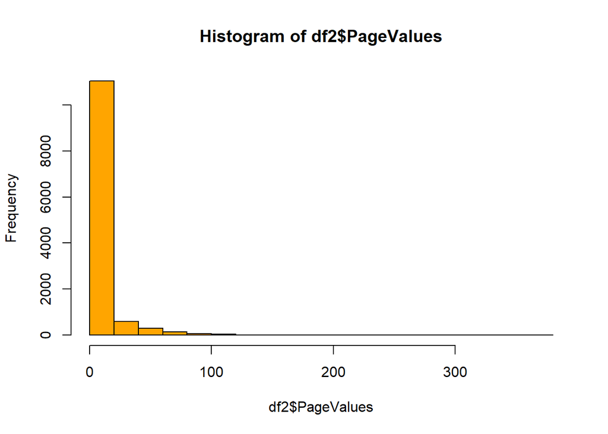

```r
#distribution
hist(df2$PageValues,col=c("Orange"))
```

Special Days

```r
length(unique(df2$SpecialDay))
```

```
## [1] 6
```

```r
#there are 311 unique elements in Product Related  column

summary(df2$SpecialDay)
```

```
##    Min. 1st Qu.  Median    Mean 3rd Qu.    Max.
## 0.00000 0.00000 0.00000 0.06197 0.00000 1.00000
```

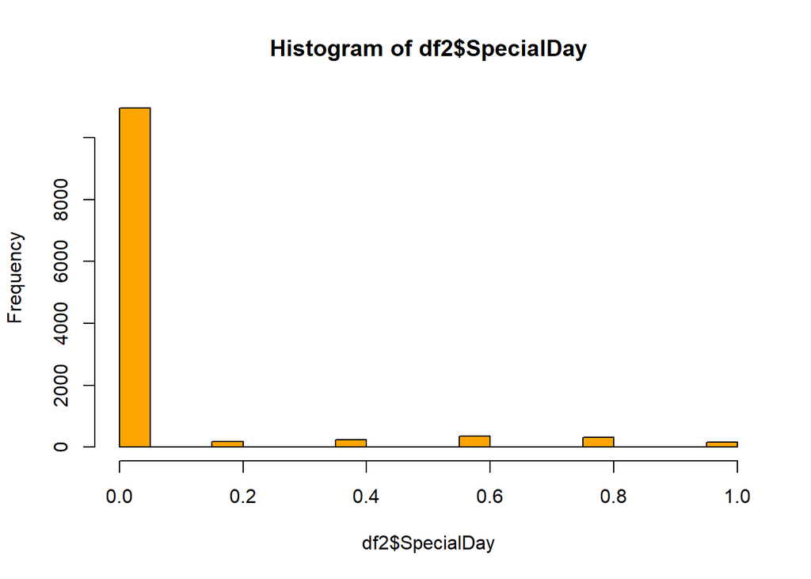

```r
#distribution
hist(df2$SpecialDay,col=c("Orange"))
```

Month

```r
length(unique(df2$Month))
```

```
## [1] 10
```

```r
#there are 311 unique elements in Product Related  column

summary(df2$Month)
```

```
##    Length     Class      Mode
##     12199 character character
```

```r
summary(df2$Month)
```

```
##    Length     Class      Mode
##     12199 character character
```

```r
## Aug Dec Feb Jul June Mar May Nov Oct Sep
## 433 1706 182 432 285 1853 3328 2983 549 448
adm_Month <- df2$Month
```

```r
# Simple Bar Plot
counts <- table(adm_Month)

counts
```

```
## adm_Month
##  Aug  Dec  Feb  Jul June  Mar  May  Nov  Oct  Sep
##  433 1706  182  432  285 1853 3328 2983  549  448
```

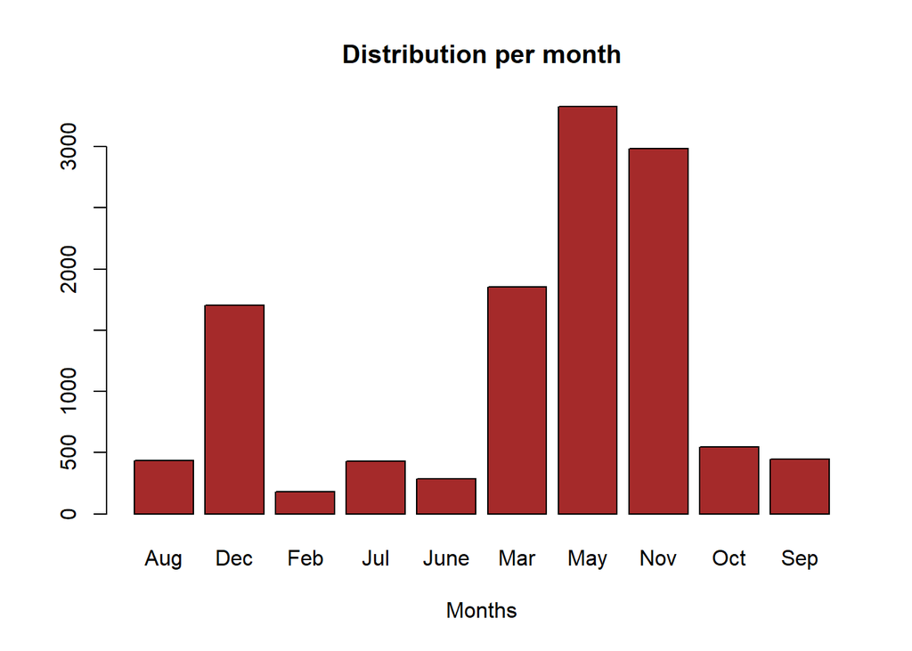

```r
barplot(counts, main="Distribution per month",col=c("brown"),
 xlab="Months")
```

OperatingSystems

```r
length(unique(df2$OperatingSystems))
```

```
## [1] 8
```

```r
summary(df2$OperatingSystems)
```

```
##    Min. 1st Qu.  Median    Mean 3rd Qu.    Max.
##   1.000   2.000   2.000   2.124   3.000   8.000
```

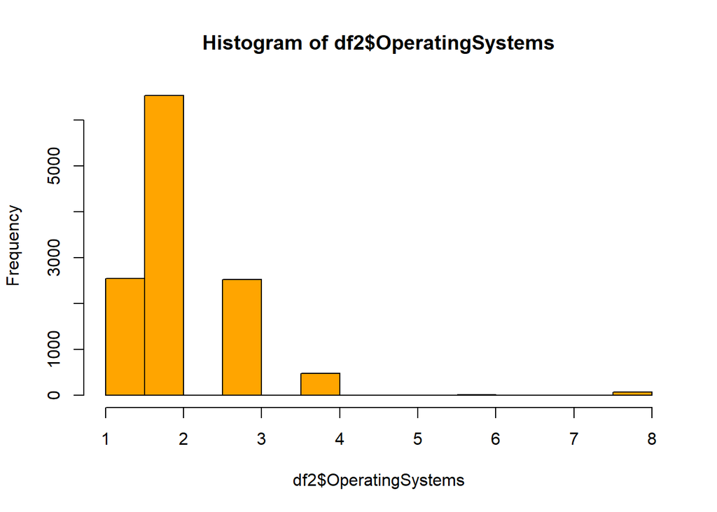

```r
#distribution
hist(df2$OperatingSystems,col=c("Orange"))
```

```r
length(unique(df2$Browser))
```

```
## [1] 13
```

```r
summary(df2$Browser)
```

```
##    Min. 1st Qu.  Median    Mean 3rd Qu.    Max.
##   1.000   2.000   2.000   2.358   2.000  13.000
```

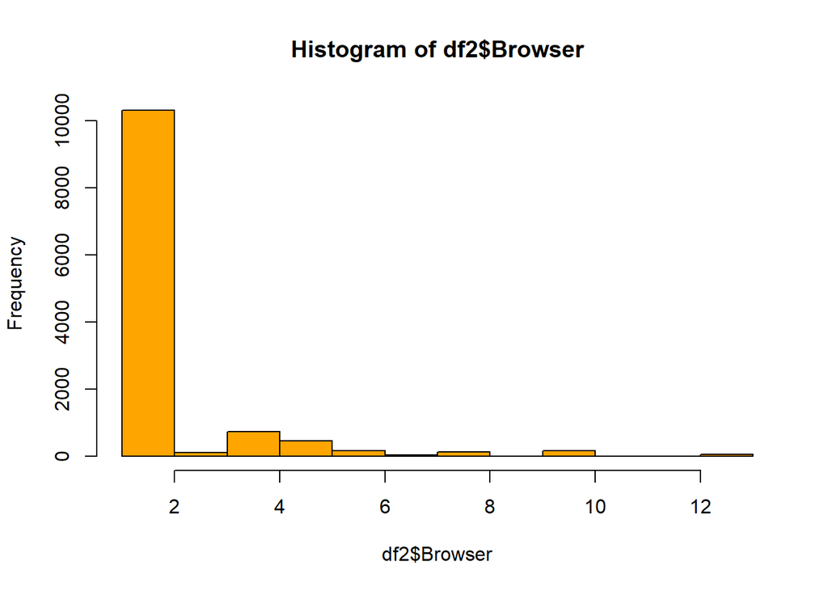

```r
#distribution
hist(df2$Browser,col=c("Orange"))
```

```r
length(unique(df2$Region))
```

```
## [1] 9
```

```r
summary(df2$Region)
```

```
##    Min. 1st Qu.  Median    Mean 3rd Qu.    Max.
##   1.000   1.000   3.000   3.153   4.000   9.000
```

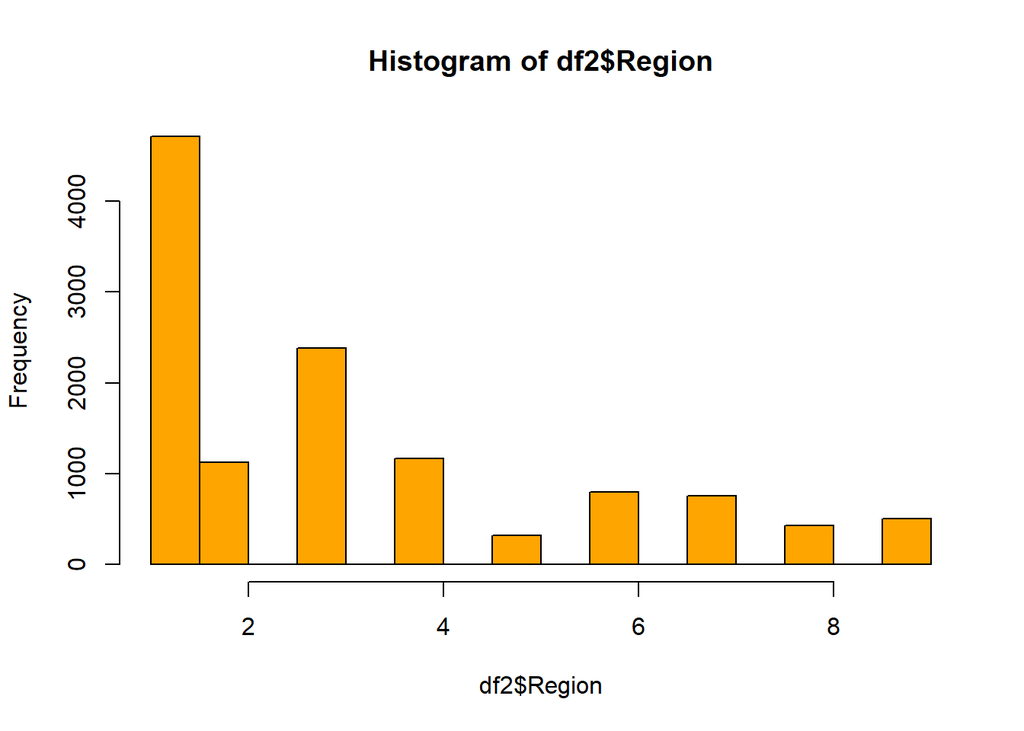

```r
#distribution
hist(df2$Region,col=c("Orange"))
```

```r
length(unique(df2$TrafficType))
```

```
## [1] 20
```

```r
summary(df2$TrafficType)
```

```
##    Min. 1st Qu.  Median    Mean 3rd Qu.    Max.
##   1.000   2.000   2.000   4.075   4.000  20.000
```

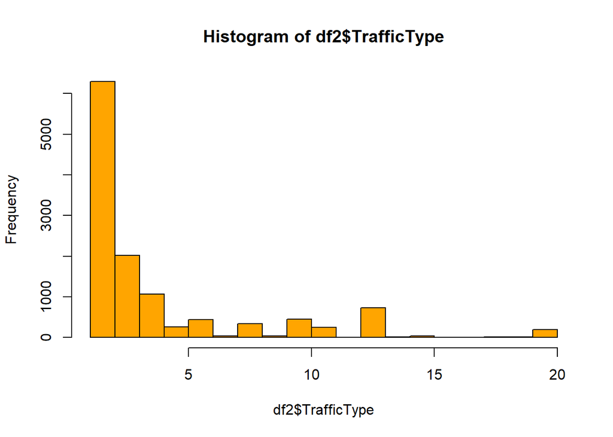

```r
#distribution
hist(df2$TrafficType,col=c("Orange"))
```

```r
length(unique(df2$VisitorType))
```

```
## [1] 3
```

```r
summary(df2$VisitorType)
```

```
##    Length     Class      Mode
##     12199 character character
```

```r
adm_VisitorType <- df2$VisitorType

#sort(adm_info_dur)
names(table(adm_VisitorType))[table(adm_VisitorType)==max(table(adm_VisitorType ))]
```

```
## [1] "Returning_Visitor"
```

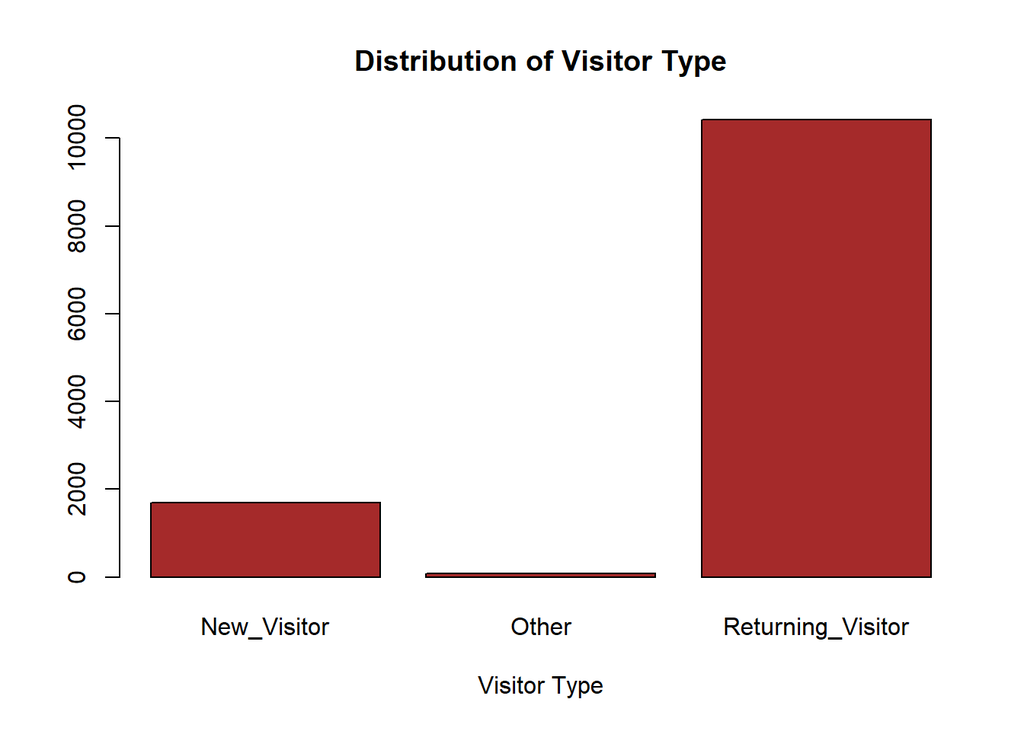

```r
#distribution
counts <- table(adm_VisitorType)
barplot(counts, main="Distribution of Visitor Type",col=c("brown"),
 xlab="Visitor Type")
```

```r
length(unique(df2$Weekend))
```

```
## [1] 2
```

```r
summary(df2$Weekend)
```

```
##    Mode   FALSE    TRUE
## logical    9343    2856
```

```r
adm_Weekend <- df2$Weekend

#sort(adm_info_dur)
names(table(adm_Weekend))[table(adm_Weekend)==max(table(adm_Weekend ))]
```

```
## [1] "FALSE"
```

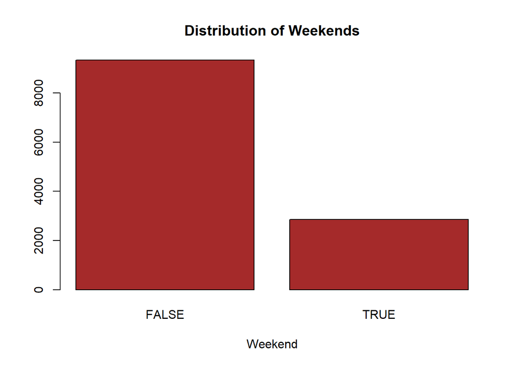

```r
#distribution
counts <- table(adm_Weekend)
barplot(counts, main="Distribution of Weekends",col=c("brown"),
 xlab="Weekend")
```

```r
length(unique(df2$Revenue))
```

```
## [1] 2
```

```r
summary(df2$Revenue)
```

```
##    Mode   FALSE    TRUE
## logical   10291    1908
```

```r
adm_Revenue <- df2$Revenue

#sort(adm_info_dur)
names(table(adm_Revenue))[table(adm_Revenue)==max(table(adm_Revenue ))]
```

```
## [1] "FALSE"
```

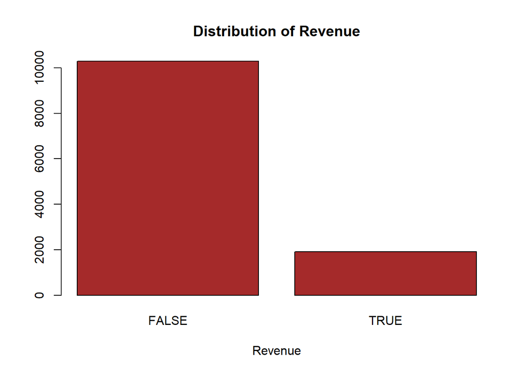

```r
#distribution
counts <- table(adm_Revenue)
barplot(counts, main="Distribution of Revenue",col=c("brown"),
 xlab="Revenue")
```

Bivariate Analysis

```r
# calculate correlations
correlations <- cor(df2[,1:10])
correlations
```

```
##                         Administrative Administrative_Duration Informational
## Administrative              1.00000000              0.60040965    0.37528761
## Administrative_Duration     0.60040965              1.00000000    0.30143630
## Informational               0.37528761              0.30143630    1.00000000
## Informational_Duration      0.25478602              0.23718986    0.61867795
## ProductRelated              0.42819151              0.28678391    0.37260472
## ProductRelated_Duration     0.37102722              0.35351379    0.38608372
## BounceRates                -0.21366664             -0.13733340   -0.10950530
## ExitRates                  -0.31127413             -0.20202445   -0.15956681
## PageValues                  0.09692097              0.06616837    0.04739015
## SpecialDay                 -0.09707210             -0.07473689   -0.04937677
##                         Informational_Duration ProductRelated
## Administrative                      0.25478602     0.42819151
## Administrative_Duration             0.23718986     0.28678391
## Informational                       0.61867795     0.37260472
## Informational_Duration              1.00000000     0.27906195
## ProductRelated                      0.27906195     1.00000000
## ProductRelated_Duration             0.34658069     0.86030819
## BounceRates                        -0.07015947    -0.19351577
## ExitRates                          -0.10293268    -0.28616321
## PageValues                          0.03006416     0.05411549
## SpecialDay                         -0.03129304    -0.02593062
##                         ProductRelated_Duration BounceRates  ExitRates
## Administrative                       0.37102722 -0.21366664 -0.3112741
## Administrative_Duration              0.35351379 -0.13733340 -0.2020245
## Informational                        0.38608372 -0.10950530 -0.1595668
## Informational_Duration               0.34658069 -0.07015947 -0.1029327
## ProductRelated                       0.86030819 -0.19351577 -0.2861632
## ProductRelated_Duration              1.00000000 -0.17437550 -0.2453340
## BounceRates                         -0.17437550  1.00000000  0.9033582
## ExitRates                           -0.24533401  0.90335819  1.0000000
## PageValues                           0.05084062 -0.11599198 -0.1735715
## SpecialDay                          -0.03821065  0.08783999  0.1167838
##                          PageValues  SpecialDay
## Administrative           0.09692097 -0.09707210
## Administrative_Duration  0.06616837 -0.07473689
## Informational            0.04739015 -0.04937677
## Informational_Duration   0.03006416 -0.03129304
## ProductRelated           0.05411549 -0.02593062
## ProductRelated_Duration  0.05084062 -0.03821065
## BounceRates             -0.11599198  0.08783999
## ExitRates               -0.17357154  0.11678376
## PageValues               1.00000000 -0.06453271
## SpecialDay              -0.06453271  1.00000000
```

Correlation Plot

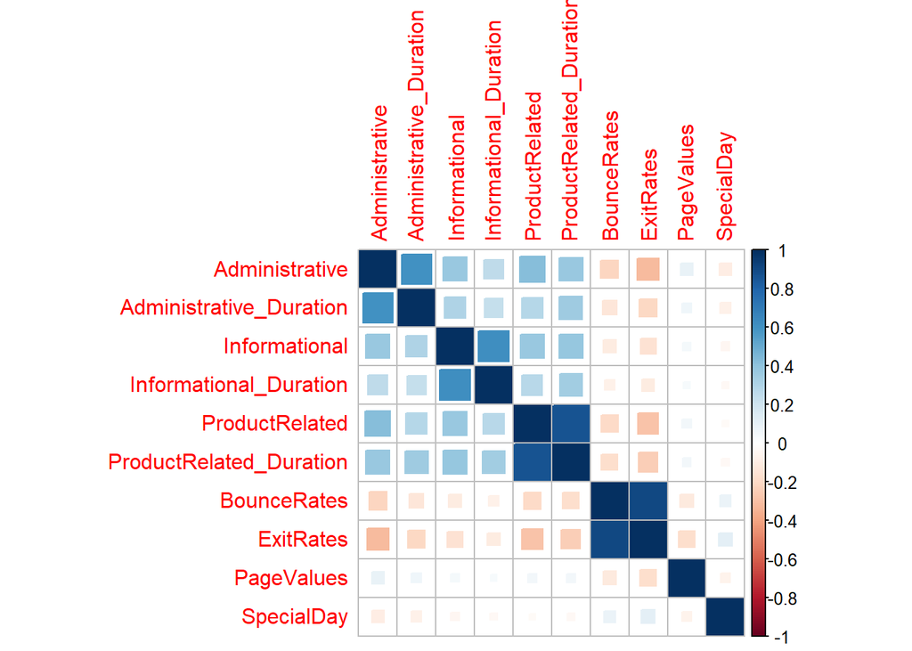

```r
# create correlation plot
library(corrplot)
## corrplot 0.84 loaded
corrplot(correlations, method="square")
```

From the plot above, we can see that most of the variables have low Positive and Negative correlation Pair Plots

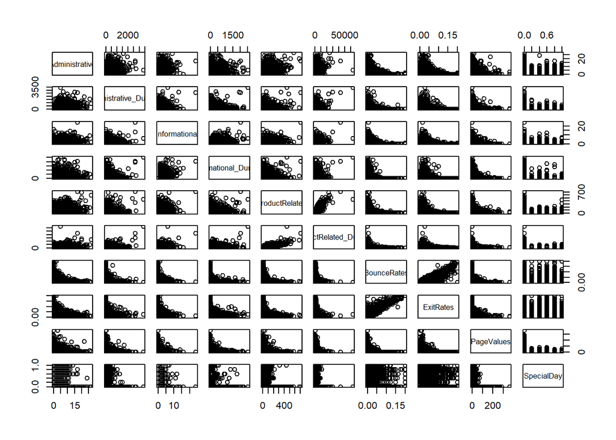

```r
pairs(df2[,1:10])
```

Sites Visited Duration Scatter plot of Administrative_Duration vs Informational_Duration

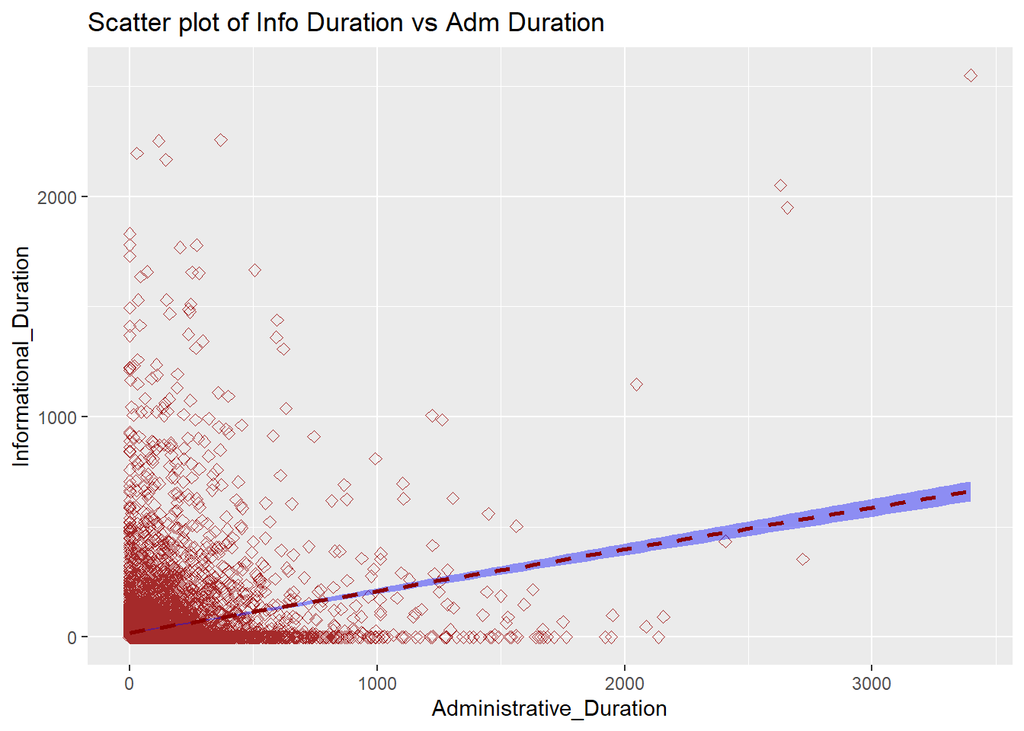

```r
library(ggplot2)
ggplot(df2, aes(x = Administrative_Duration, y =
Informational_Duration)) +
 geom_point(size = 2, color= "brown", shape = 23)+
 geom_smooth(method=lm, linetype="dashed",color="darkred",
fill="blue")+
 labs(title = "Scatter plot of Info Duration vs Adm Duration")
```

Scatter plot Bounce vs Exit Rates Scatter Plot

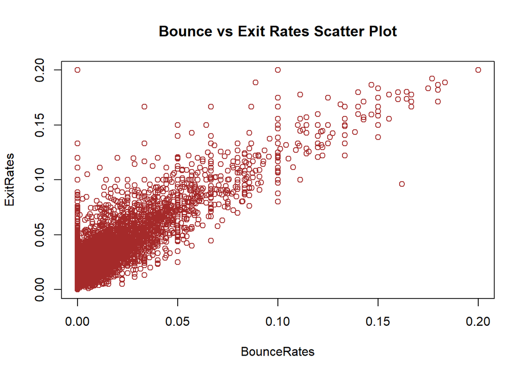

```r
plot(ExitRates ~ BounceRates, dat = df2,
 col = "brown",
 main = "Bounce vs Exit Rates Scatter Plot")
```

Stacked bar chart: Revenue vs Day Type

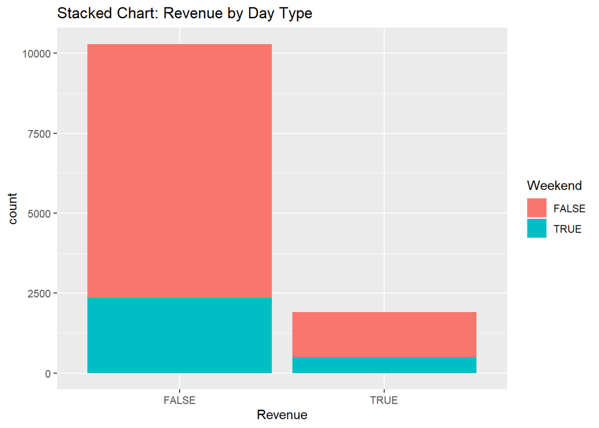

```r
library(magrittr)
df2 %>%
 ggplot(aes(Revenue)) +
 geom_bar(aes(fill = Weekend))+
 labs(title = "Stacked Chart: Revenue by Day Type")
```

we can see that most of the revenue is generated during the week and not over the weekend

Revenue vs Month

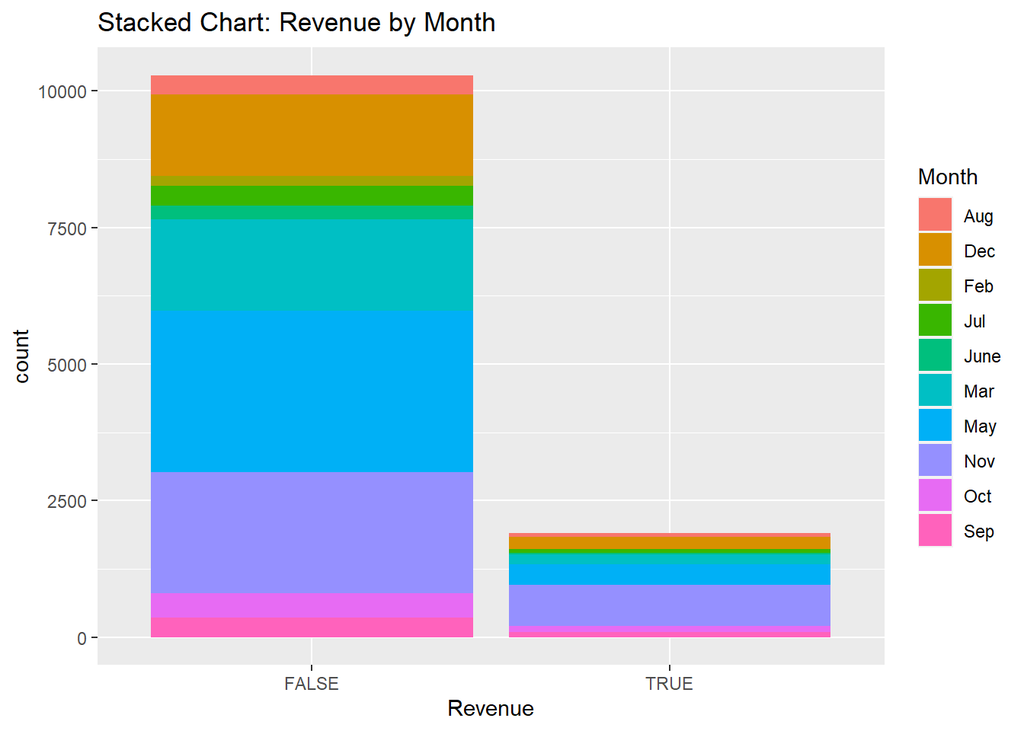

```r
# Stacked bar chart: Revenue vs Month
df2 %>%
 ggplot(aes(Revenue)) +
 geom_bar(aes(fill = Month))+
 labs(title = "Stacked Chart: Revenue by Month")
```

Type of visitor Stacked bar chart: Visitor Type vs Month

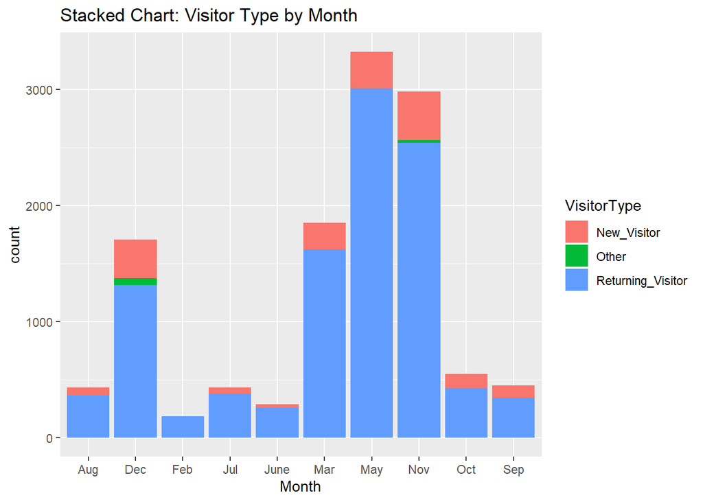

```r
df2 %>%
 ggplot(aes(Month)) +
 geom_bar(aes(fill = VisitorType))+
 labs(title = "Stacked Chart: Visitor Type by Month")
```

Multivariate Analysis

```r
# A glimpse of the data
library(dplyr)

glimpse(df2)
```

```
## Rows: 12,199
## Columns: 18
## $ Administrative          <int> 0, 0, 0, 0, 0, 0, 0, 1, 0, 0, 0, 0, 0, 0, 0, 2~
## $ Administrative_Duration <dbl> 0, 0, -1, 0, 0, 0, -1, -1, 0, 0, 0, 0, 0, 0, 0~
## $ Informational           <int> 0, 0, 0, 0, 0, 0, 0, 0, 0, 0, 0, 0, 0, 0, 0, 0~
## $ Informational_Duration  <dbl> 0, 0, -1, 0, 0, 0, -1, -1, 0, 0, 0, 0, 0, 0, 0~
## $ ProductRelated          <int> 1, 2, 1, 2, 10, 19, 1, 1, 2, 3, 3, 16, 7, 6, 2~
## $ ProductRelated_Duration <dbl> 0.000000, 64.000000, -1.000000, 2.666667, 627.~
## $ BounceRates             <dbl> 0.200000000, 0.000000000, 0.200000000, 0.05000~
## $ ExitRates               <dbl> 0.200000000, 0.100000000, 0.200000000, 0.14000~
## $ PageValues              <dbl> 0, 0, 0, 0, 0, 0, 0, 0, 0, 0, 0, 0, 0, 0, 0, 0~
## $ SpecialDay              <dbl> 0.0, 0.0, 0.0, 0.0, 0.0, 0.0, 0.4, 0.0, 0.8, 0~
## $ Month                   <chr> "Feb", "Feb", "Feb", "Feb", "Feb", "Feb", "Feb~
## $ OperatingSystems        <int> 1, 2, 4, 3, 3, 2, 2, 1, 2, 2, 1, 1, 1, 2, 3, 1~
## $ Browser                 <int> 1, 2, 1, 2, 3, 2, 4, 2, 2, 4, 1, 1, 1, 5, 2, 1~
## $ Region                  <int> 1, 1, 9, 2, 1, 1, 3, 1, 2, 1, 3, 4, 1, 1, 3, 9~
## $ TrafficType             <int> 1, 2, 3, 4, 4, 3, 3, 5, 3, 2, 3, 3, 3, 3, 3, 3~
## $ VisitorType             <chr> "Returning_Visitor", "Returning_Visitor", "Ret~
## $ Weekend                 <lgl> FALSE, FALSE, FALSE, FALSE, TRUE, FALSE, FALSE~
## $ Revenue                 <lgl> FALSE, FALSE, FALSE, FALSE, FALSE, FALSE, FALS~
```

```r
options(contrasts = rep("contr.sum", 2)) # Set contrasts -- see below
contr.sum (3)   # This shows what the Physique contrasts measure, by column
```

```
##   [,1] [,2]
## 1    1    0
## 2    0    1
## 3   -1   -1
```

```r
values_count <- sapply(lapply(df2, unique), length)  # Identify variables with 1 value
values_count
```

```
##          Administrative Administrative_Duration           Informational
##                      27                    3336                      17
##  Informational_Duration          ProductRelated ProductRelated_Duration
##                    1259                     311                    9552
##             BounceRates               ExitRates              PageValues
##                    1872                    4777                    2704
##              SpecialDay                   Month        OperatingSystems
##                       6                      10                       8
##                 Browser                  Region             TrafficType
##                      13                       9                      20
##             VisitorType                 Weekend                 Revenue
##                       3                       2                       2
```